# V3: Secondary Aims Analysis

Using moderators and Q-learning to construct more deeply-tailored Adaptive Interventions

Authors

Mason Ferlic

Jamie Yap

John J. Dziak

Daniel Almirall

# 1 Learning Goals

Typical secondary aims analysis involves using data from a SMART to learn a set of decision rules for a more deeply-tailored adaptive intervention that leads to better outcomes. In this workbook, we will use a subset of candidate moderators to test which variables are useful for tailoring first and second-stage intervention options in a 2-stage SMART.

To learn an optimal decision rule in a 2-arm RCT we could simply fit a moderated regression to determine if baseline covariates are useful for tailoring treatment assignment. In a prototypical SMART we have two stages of treatment assignment and you may be thinking, can’t we just fit moderated regressions for first and second-stage, and taken together, we have a proposal for a more deeply-tailored AI? The answer is no! These separate regressions don’t “talk” to each other. That is, we want to make the optimal first-stage decision accounting for the fact that, in the future, we will be making an optimal second-stage decision.

In this workbook we will:

1. Learn how moderators of first and second-stage treatment effects can be used to construct optimal adaptive interventions
   - Fit moderated regression models
   - Test contrasts and generate interaction plots
2. Learn how Q-learning is used to estimate the effect of a more-deeply tailored AI.
   - Implement using the R Package `qlaci`

# 2 Setup

Load required packages

```r
# R packages for analysis
library(geepack)
library(emmeans)
library(qlaci)

# R packages for visuals/data
library(ggplot2)
library(dplyr)
library(kableExtra)
```

# 3 Load data

This is data that was *simulated* to mimic data arising from the ADHD SMART study (PI: William Pelham). An accompanying handout (“ADHD_SMART_handout.pdf”) describes the variables in the data set.

```r
# Load data
dat_adhd <- read.csv("data/adhd-simulated-2023.csv")
```

ADHD study prototypical SMART

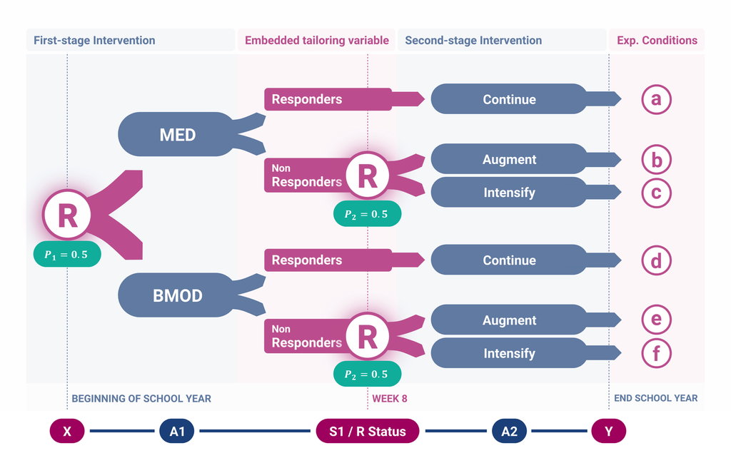

## Examine data

**ADHD dataset variable descriptions**

**Baseline covariates:**

- `ID` subject identifier
- `odd` Oppositional Defiant Disorder diagnosis, reflecting whether the child was (coded as 1) or was not (coded as 0) diagnosed with ODD before the first-stage intervention.
- `severity` ADHD score, reflecting ADHD symptoms at the end of the previous school year (larger values reflect greater symptoms). Range 0-10.
- `priormed` medication prior to first-stage intervention, reflecting whether the child did (coded as 1) or did not (coded as 0) receive medication during the previous school year.
- `race` white (coded 1) versus non-white (coded 0).

**Intermediate covariates:**

- `R` response status. R = 0 if child was classified as non-responder to first stage intervention, R= 1 if they were classified as a responder.
- `NRtime` months at which child was classified as non-responder. Range 2-8. Undefined for responders.
- `adherence` adherence to the stage 1 intervention. Reflecting whether the child did (coded as 1) or did not (coded as 0) show high adherence to initial treatment.

**Treatments:**

We use effect coding (contrast coding) to denote the two levels of treatment assignment. The primary benefit of effect coding is that we get interpretable estimates of both the main effects and interactions.

- `A1` stage 1 treatment assignment. Randomized with probability $0.5$ to Medication (MED, $A1=-1$) or Behavioral Intervention (BMOD, $A1=1$).
- `A2` stage 2 treatment assignment for non-responders. Non-responders we randomized with probability $0.5$ to receive Augmented (AUG, $A2=-1$) or Intensified (INT, $A2=1$) care. Undefined for responders.

**Outcomes**

- `Y0` baseline school performance (higher values reflect better performance).
- `Y1` mid-year school performance.
- `Y2` end-of-year school performance (primary outcome for analysis)

ADHD SMART data

| ID | odd | severity | priormed | race | Y0 | A1 | R | NRtime | adherence | Y1 | A2 | Y2 | cell |
| --- | --- | --- | --- | --- | --- | --- | --- | --- | --- | --- | --- | --- | --- |
| 1 | 1 | 2.880 | 0 | 1 | 2.321 | -1 | 0 | 4 | 0 | 2.791 | 1 | 0.598 | C |
| 2 | 0 | 4.133 | 0 | 0 | 2.068 | 1 | 1 | NA | 1 | 2.200 | NA | 4.267 | D |
| 3 | 1 | 5.569 | 0 | 1 | 1.004 | -1 | 1 | NA | 0 | 2.292 | NA | 1.454 | A |
| 4 | 0 | 4.931 | 0 | 1 | 3.232 | 1 | 0 | 4 | 0 | 3.050 | -1 | 6.762 | E |
| 5 | 1 | 5.502 | 0 | 1 | 1.477 | 1 | 0 | 6 | 0 | 1.732 | -1 | 3.580 | E |
| 6 | 0 | 5.497 | 0 | 1 | 1.720 | 1 | 0 | 3 | 0 | 2.400 | 1 | 2.075 | F |
| 7 | 0 | 6.786 | 0 | 1 | 2.265 | 1 | 0 | 7 | 0 | 2.837 | 1 | 2.594 | F |
| 8 | 0 | 4.317 | 0 | 1 | 2.814 | 1 | 1 | NA | 0 | 2.751 | NA | 4.051 | D |
| 9 | 1 | 9.088 | 1 | 1 | 1.896 | 1 | 0 | 6 | 0 | 3.594 | -1 | 2.970 | E |
| 10 | 0 | 6.094 | 0 | 1 | 2.503 | 1 | 0 | 5 | 1 | 2.546 | 1 | 6.022 | F |
| 11 | 0 | 2.016 | 0 | 1 | 2.810 | 1 | 0 | 4 | 0 | 1.916 | -1 | 5.561 | E |
| 12 | 0 | 4.308 | 0 | 1 | 2.650 | -1 | 1 | NA | 0 | 3.088 | NA | 2.476 | A |
| 13 | 0 | 6.290 | 0 | 1 | 2.188 | 1 | 0 | 2 | 0 | 1.733 | 1 | 3.188 | F |
| 14 | 0 | 3.972 | 0 | 1 | 2.281 | -1 | 0 | 8 | 1 | 2.845 | 1 | 3.116 | C |
| 15 | 0 | 5.862 | 0 | 1 | 1.588 | 1 | 0 | 8 | 1 | 1.681 | 1 | 4.182 | F |
| 16 | 0 | 6.086 | 1 | 1 | 2.105 | 1 | 0 | 8 | 1 | 2.296 | -1 | 1.920 | E |
| 17 | 0 | 8.259 | 1 | 1 | 1.695 | 1 | 0 | 4 | 0 | 2.279 | -1 | 3.230 | E |
| 18 | 1 | 3.371 | 1 | 1 | 2.222 | 1 | 0 | 3 | 0 | 1.669 | 1 | 0.920 | F |
| 19 | 1 | 4.958 | 0 | 1 | 2.084 | 1 | 0 | 5 | 1 | 2.605 | -1 | 3.940 | E |
| 20 | 1 | 3.581 | 1 | 0 | 0.614 | 1 | 0 | 4 | 0 | 0.681 | 1 | -2.254 | F |
| 21 | 0 | 2.182 | 0 | 0 | 2.204 | 1 | 0 | 5 | 0 | 2.580 | -1 | 5.381 | E |
| 22 | 0 | 0.378 | 0 | 1 | 2.608 | 1 | 1 | NA | 1 | 1.469 | NA | 5.617 | D |
| 23 | 0 | 5.489 | 0 | 1 | 2.278 | -1 | 1 | NA | 0 | 2.958 | NA | 2.872 | A |
| 24 | 0 | 6.504 | 0 | 1 | 2.098 | 1 | 0 | 5 | 0 | 2.445 | -1 | 4.461 | E |
| 25 | 0 | 6.598 | 0 | 0 | 1.858 | 1 | 0 | 4 | 0 | 1.701 | 1 | 2.978 | F |
| 26 | 0 | 1.525 | 1 | 1 | 3.259 | -1 | 0 | 5 | 1 | 4.138 | -1 | 5.591 | B |
| 27 | 1 | 2.176 | 1 | 1 | 2.010 | -1 | 0 | 7 | 1 | 2.007 | -1 | 2.408 | B |
| 28 | 0 | 2.147 | 1 | 1 | 2.181 | -1 | 0 | 8 | 1 | 3.052 | -1 | 5.045 | B |
| 29 | 0 | 3.278 | 1 | 1 | 2.387 | 1 | 0 | 8 | 0 | 2.151 | 1 | 0.497 | F |
| 30 | 0 | 5.425 | 0 | 1 | 2.381 | 1 | 0 | 5 | 1 | 2.467 | -1 | 4.281 | E |

[output cut: 120 more lines]

## Clean/transform data

Here we grand mean center the baseline covariates. This does not change the point estimates, but is useful when interpreting model coefficients or when hand coding contrasts.

```r
# Grand mean center all baseline covariates, append '_c' for centered
dat_adhd_c <- dat_adhd %>% mutate(odd_c = odd - mean(odd),
                          severity_c = severity - mean(severity),
                          priormed_c = priormed - mean(priormed),
                          race_c = race - mean(race))
```

# 4 Q-learning

We use Q-learning to learn a set of decision rules for a more deeply-tailored adaptive intervention which combines optimal tactics at each stage.

Q-learning has three steps:

1. Fit a stage 2 moderated regression
2. Predict the stage 2 outcome under the optimal decision rule: $\hat{Y}^{opt}_i$
3. Fit a stage 1 moderated regression on $\hat{Y}^{opt}_i$

## 4.1 Step 1: second-stage tailoring

A common secondary aim is to learn whether we can use baseline or intermediate covariates to select an optimal second-stage tactic for **non-responders.** For example, whether covariates such as the initial treatment $A_1$ and adherence to initial treatment `adherence` moderate the effect of $A2$.

> We hypothesize that for children who are non-adherent to first-stage treatment it will be better to AUGment ($A2=-1$) with the alternative treatment as opposed to INTensifying ($A2=1$) the current treatment.

### Regression model

We test this secondary aim by fitting a **moderated regression model** using data from non-responders. This model examines whether binary intermediate outcome variable `adherence`, and first-stage treatment $A_1$, moderate the effect of second-stage treatment $A_2$ on end-of-year outcome $Y_2$, controlling for other baseline covariates $\mathbf{X}$. The model is as follows:

$$\begin{gather*}
E[Y(A_2) \mid \mathbf{X}, A_1, \text{adherence}, R = 0] = \beta_0 + \beta_{1:4}^T\mathbf{X} + \beta_5 A_{1} + \beta_6\text{adherence} + \beta_7 A_2 + \\
\beta_8 (A_2 \times A_1) + \beta_9 (A_2 \times \text{adherence})
\end{gather*}
\tag{1}$$

**Tip**

First, subset data.frame to non-responders $(R=0)$

```r
dat_adhd_nr <- subset(dat_adhd, R == 0) # subset data.frame to non-responders

head(dat_adhd_nr) # view top 6 rows
```

|  | ID | odd | severity | priormed | race | Y0 | A1 | R | NRtime | adherence | Y1 | A2 | Y2 | cell |
| --- | --- | --- | --- | --- | --- | --- | --- | --- | --- | --- | --- | --- | --- | --- |
| 1 | 1 | 1 | 2.88 | 0 | 1 | 2.32 | -1 | 0 | 4 | 0 | 2.79 | 1 | 0.598 | C |
| 4 | 4 | 0 | 4.93 | 0 | 1 | 3.23 | 1 | 0 | 4 | 0 | 3.05 | -1 | 6.762 | E |
| 5 | 5 | 1 | 5.50 | 0 | 1 | 1.48 | 1 | 0 | 6 | 0 | 1.73 | -1 | 3.580 | E |
| 6 | 6 | 0 | 5.50 | 0 | 1 | 1.72 | 1 | 0 | 3 | 0 | 2.40 | 1 | 2.075 | F |
| 7 | 7 | 0 | 6.79 | 0 | 1 | 2.27 | 1 | 0 | 7 | 0 | 2.84 | 1 | 2.594 | F |
| 9 | 9 | 1 | 9.09 | 1 | 1 | 1.90 | 1 | 0 | 6 | 0 | 3.59 | -1 | 2.970 | E |

Next, fit a moderated regression to the subset of non-responders. Interact $A_2$ with $A_1$ and `adherence`

```r
# geeglm fits a Generalize Estimating Equation. Similar to lm(), but gives us robust standard errors.
mod2 <- geepack::geeglm(Y2 ~ odd + severity + priormed + race + A1 + adherence + A2 + A1:A2 + adherence:A2,
                        id = ID, # a subject identifier is required for geeglm()
                        data = dat_adhd_nr)

summary(mod2)
```

```
Call:
geepack::geeglm(formula = Y2 ~ odd + severity + priormed + race +
    A1 + adherence + A2 + A1:A2 + adherence:A2, data = dat_adhd_nr,
    id = ID)

 Coefficients:
             Estimate Std.err  Wald Pr(>|W|)
(Intercept)    2.7939  0.4905 32.44  1.2e-08 ***
odd           -0.6239  0.2748  5.16  0.02316 *
severity      -0.0496  0.0684  0.53  0.46821
priormed      -0.5773  0.3348  2.97  0.08464 .
race           0.2627  0.4170  0.40  0.52873
A1             0.4249  0.1518  7.83  0.00513 **
adherence      0.9272  0.2561 13.11  0.00029 ***
A2            -1.1725  0.1675 49.01  2.6e-12 ***
A1:A2         -0.1523  0.1245  1.50  0.22120
adherence:A2   1.7331  0.2553 46.08  1.1e-11 ***
---
Signif. codes:  0 '***' 0.001 '**' 0.01 '*' 0.05 '.' 0.1 ' ' 1

Correlation structure = independence
Estimated Scale Parameters:

            Estimate Std.err
(Intercept)      1.6   0.203
Number of clusters:   101  Maximum cluster size: 1
```

**Warning**

Only the second-stage coefficients $\beta_7, \beta_8, \beta_9$ from the moderated regression in Equation 1 are causal. The pre second-stage randomization covariates are all associations with the outcome.

The regression model from Equation 1 gives us the effect of $A2$ among non-responders. Looking at the output we find that `adherence` is a significant moderator of stage 2 treatment, but $A_1$ is not.

### Knowledge check #1

**Questions**

1. Why do we subset to non-responders when fitting a second-stage moderated regression?
2. What does this regression tell us about the use of $A1$ as a tailoring variable?

### Marginal means of stage 2

We will use a very powerful package called `emmeans` to estimate the marginal mean of end-of-year school performance under different treatment/covariate options. We could do this by writing custom contrasts of the model coefficients, but `emmeans` does this for us.

**Tip**

Marginal means refers to estimating the expected value while holding some covariates constant and averaging over the rest.

We use the fitted moderated regression model given in Equation 1 to estimate the average effect of second-stage treatment, among non-responders, conditional on levels of adherence.

```r
# The formula notation denotes the mean outcome under all combination of the factors A1, A2, given levels of adherence.
# We specify weights=proportional since we want to average over the observed distribution of the other baseline covariates.
# df of Inf indicates CIs are computed using the standard normal distribution

em2 <- emmeans::emmeans(mod2, ~ A1 + A2 | adherence, weights = "proportional")
print(em2)
```

```
adherence = 0:
 A1 A2 emmean    SE  df asymp.LCL asymp.UCL
 -1 -1   2.96 0.373 Inf      2.22      3.69
  1 -1   4.11 0.282 Inf      3.56      4.66
 -1  1   0.92 0.256 Inf      0.41      1.42
  1  1   1.46 0.305 Inf      0.86      2.06

adherence = 1:
 A1 A2 emmean    SE  df asymp.LCL asymp.UCL
 -1 -1   2.15 0.383 Inf      1.40      2.90
  1 -1   3.30 0.353 Inf      2.61      4.00
 -1  1   3.58 0.327 Inf      2.93      4.22
  1  1   4.12 0.267 Inf      3.60      4.64

Results are averaged over the levels of: odd, priormed, race
Covariance estimate used: vbeta
Confidence level used: 0.95
```

The results from the moderated regression and the marginal means output suggest that for those children who are non-adherent (`adherence` = 0) it is better to Augment ($A2 = -1$) rather than intensify. Likewise, for those children that are adherent (`adherence` = 1) it is better to Intensify ($A2=1$). Notice, our optimal tactic does not depend on first-stage treatment $A1$.

### Interaction plot of stage 2

We can also use the `emmeans` package to visualize the estimated mean outcome for non-responders under each tactic.

```r
ep2 <- emmeans::emmip(em2,  A1*A2 ~ adherence, style = "factor") # Interaction plot for trace.factors ~ x.factors
```

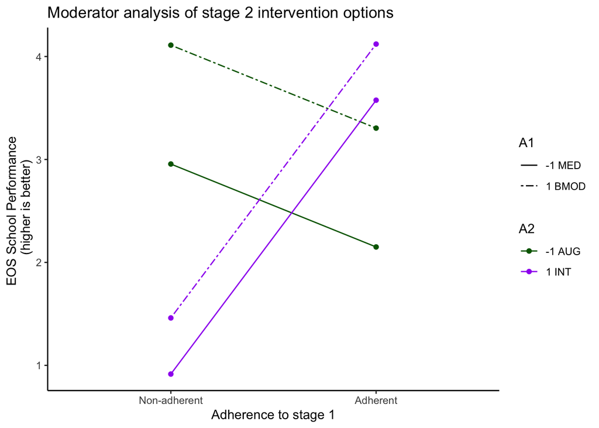

```r
# Prettify the plot
ep2$data %>% mutate(across(1:3, as.factor)) %>%
  ggplot(aes(xvar, yvar, color = A2, linetype = A1, group = tvar)) +
  geom_line() +
  geom_point() +
  scale_color_manual("A2", values = c("-1" = "darkgreen", "1" = "purple"),
                     labels = c("-1" = "-1 AUG", "1" = "1 INT")) +
  scale_linetype_manual("A1", values = c("-1" = 1,"1" = 6),
                        labels = c("-1" = "-1 MED", "1" = "1 BMOD")) +
  labs(title = "Moderator analysis of stage 2 intervention options",
       x = "Adherence to stage 1",
       y = "EOS School Performance \n (higher is better)") +
  scale_x_discrete(labels = c("Non-adherent", "Adherent")) +
  theme_classic()
```

### Knowledge check #2

**Questions**

1. What is the optimal tactic for non-adhering, non-responders to BMOD(1)? To MED(-1)?
2. $A1$ was found to be not useful for tailoring, should we still include it in the regression model?

## 4.2 Step 2: predict optimal outcome

The optimal second-stage tactic learned from the moderated regression:

$$A2 = \begin{cases}
1 \text{ INT} & \text{ if } \text{ adherence} = 1 \\
-1 \text{ AUG} & \text{ if } \text{ adherence} = 0
\end{cases}$$

Create new data.frame with optimal $A2_i$ for every non-responding child

```r
# Assign optimal second-stage tactic using learned decision rule
dat_adhd_nr_opt2 <- dat_adhd_nr %>%
  mutate(A2 = if_else(adherence == 1, 1, -1))
```

Predicted outcome for non-responders under the optimal treatment assignment

```r
dat_adhd_nr_opt2$Y2_opt <- predict(mod2, newdata = dat_adhd_nr_opt2) # using the stage 2 moderated regression model
```

Merge non-responders with the observed outcome from responders

```r
# Responders get assigned their observed outcome (no stage 2 tactic)
dat_adhd_r <- dat_adhd %>% filter(R == 1) %>%
  mutate(Y2_opt = Y2)

# combine non-responders w/ responders
dat_adhd_opt2 <- bind_rows(dat_adhd_nr_opt2, dat_adhd_r)
```

We now have a data frame with the estimated optimal outcome for non-responders tailored by `adherence.`

## 4.3 Step 3: first-stage tailoring

A common secondary aim is whether we can now use baseline information to learn an optimal first-stage tactic to build a more deeply-tailored AI.

> We hypothesize that children already on medication (`priormed` = 1) will be better-off, on average, starting with MED ($A1 = -1$) instead of BMOD ($A1 = 1$) due to parent/child habituation with taking medication.

### Regression model

We fit a moderated regression model for first-stage treatment using the `dat_adhd_opt2` data frame, which accounts for the optimal future second-stage tactic. The tailoring variable of interest is `priormed`.

$$\begin{gather}
E[Y^{opt}(A_1) \mid \mathbf{X}, \text{priormed}] = \beta_0 +
\beta_{1:3}^TX + \beta_5\text{priormed} +
\beta_6A_1 + \beta_7(A_1 \times \text{priormed})
\end{gather}
\tag{2}$$

```r
# Moderator regression for first stage tailoring on priormed, controlling for optimal future tactic
Qmod1 <- geepack::geeglm(Y2_opt ~ odd + severity + race + priormed + A1 + A1:priormed,
                         id = ID,
                         data = dat_adhd_opt2)

summary(Qmod1)
```

```
Call:
geepack::geeglm(formula = Y2_opt ~ odd + severity + race + priormed +
    A1 + A1:priormed, data = dat_adhd_opt2, id = ID)

 Coefficients:
            Estimate Std.err   Wald Pr(>|W|)
(Intercept)   3.7927  0.2766 187.99  < 2e-16 ***
odd          -0.5735  0.1342  18.27  1.9e-05 ***
severity     -0.1161  0.0364  10.18  0.00142 **
race          0.7274  0.1896  14.72  0.00012 ***
priormed     -0.0362  0.1710   0.04  0.83245
A1            0.6947  0.0709  96.00  < 2e-16 ***
priormed:A1  -0.9072  0.1707  28.25  1.1e-07 ***
---
Signif. codes:  0 '***' 0.001 '**' 0.01 '*' 0.05 '.' 0.1 ' ' 1

Correlation structure = independence
Estimated Scale Parameters:

            Estimate Std.err
(Intercept)    0.644   0.106
Number of clusters:   150  Maximum cluster size: 1
```

**Warning**

The standard errors here are potentially incorrect because they don’t take into account sampling error in estimation of $\hat{Y}^{opt}$. Luckily, we provide software (see `qlaci`) to do proper inference!

We use `emmeans` package to estimate the expected end-of-year school performance for an adaptive intervention that offers BMOD(1) or MED(-1) at first-stage for levels of `priormed`, adjusting for the fact we are optimally tailoring second-stage treatment for non-responders by `adherence`.

```r
qem1 <- emmeans::emmeans(Qmod1, ~ A1 | priormed, weights = "proportional")
summary(qem1, infer = FALSE)[, 1:3]
```

| A1 | priormed | emmean |
| --- | --- | --- |
| -1 | 0 | 2.93 |
| 1 | 0 | 4.32 |
| -1 | 1 | 3.80 |
| 1 | 1 | 3.37 |

### Interaction plot of optimal tactic

```r
# Interaction plot of A1 with priormed
qep1 <- emmeans::emmip(Qmod1, A1 ~ priormed, style = "factor", weights = "proportional")
```

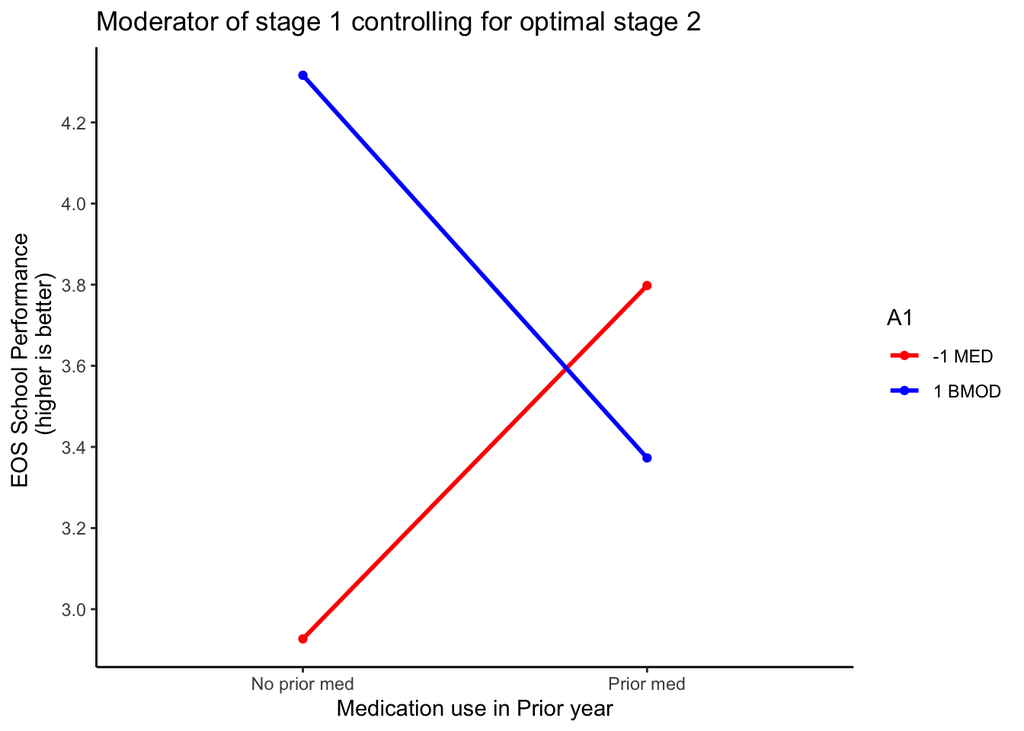

```r
# Prettify plot
qep1$data %>% mutate(across(1:2, as.factor)) %>%
  ggplot(aes(xvar, yvar, color = A1, group = tvar)) +
  geom_line(linewidth = 1) +
  geom_point() +
  scale_color_manual("A1", values = c("-1" = "red", "1" = "blue"),
                     labels = c("-1" = "-1 MED", "1" = "1 BMOD")) +
  theme_classic() +
  labs(title = "Moderator of stage 1 controlling for optimal stage 2",
       x = "Medication use in Prior year",
       y = "EOS School Performance \n (higher is better)") +
  scale_x_discrete(labels = c("No prior med", "Prior med")) +
  scale_y_continuous(n.breaks = 8)
```

### Estimated mean under the more deeply-tailored AI

The results of Q-learning generated a proposal for a more deeply-tailored AI that tailors first-stage on `priormed` and second-stage on response status and `adherence`:

The more deeply-tailored adaptive intervention learned using Q-learning

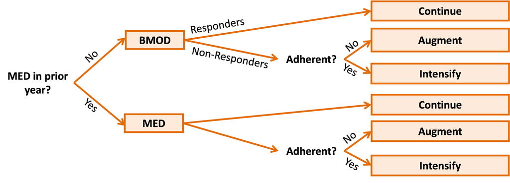

To estimate the mean outcome under the proposed decision rules we essentially repeat step 2 and create a new data frame with the optimal first-stage tactic by levels of `priormed`. We use the parametric g-formula and the fitted model from Equation 2 to compute the mean outcome if every child had received the more deeply-tailored adaptive intervention.

$$A1 = \begin{cases}
1 \text{ BMOD} & \text{ if } \text{ priormed} = 0 \\
-1 \text{ MED} & \text{ if } \text{ priormed} = 1
\end{cases}$$

```r
# Assign optimal second-stage tactic
dat_adhd_opt1 <- dat_adhd_opt2 %>%
  mutate(A1 = if_else(priormed == 1, -1, 1)) # learned decision rule

# Predict outcome under optimal treatment a2
dat_adhd_opt1$Y2_opt <- predict(Qmod1, newdata = dat_adhd_opt1)

cat("Estimated school performance under optimal AI:", mean(dat_adhd_opt1$Y2_opt))
```

```
Estimated school performance under optimal AI: 4.16
```

### Knowledge check #3

**Questions**

1. Why do we need to use Q-learning to estimate a more deeply-tailored AI? What is wrong with simply running two moderator regressions?
2. In the regression model `Qmod1` what does the main effect of $A1$ represent?
3. If `priormed` did not moderate the effect of $A1$ would this still be a valid more deeply-tailored AI?

The steps we just covered illustrate the basics of Q-learning, but we only get point estimates, not standard errors. For that we need some extra software… enter `qlaci()`!

# 5 The `qlaci` package

The `qlaci` package performs Q-learning on data arising from a two-stage SMART. It is useful when we need standard errors for the estimates of our more deeply-tailored adaptive intervention.

**Tip**

The qlaci package can be downloaded from the d3c github: d3center-isr/qlaci

First, we specify the contrast matrix that will be used for the stage 1 regression (step 3 of Q-learning). `qlaci()` uses this matrix to estimate the mean outcomes under each of the first-stage treatments (accounting for the future optimal decision) at both levels of `priormed`. We also specify a contrast that estimates the mean outcome if everyone in the study had received the optimal more deeply-tailored AI.

```r
prob.pm <- mean(dat_adhd_c$priormed) # probability of priormed, used to calculate mean under optimal decision rules

## contrast matrix - we must transpose this for qlaci
c1 <-
  rbind(
    "Mean Y under bmod, prior med"          = c(1, rep(0, 3), 1,  1,  1),
    "Mean Y under med, prior med"           = c(1, rep(0, 3), 1, -1, -1),
    "Mean diff (bmod-med) for prior med"    = c(0, rep(0, 3), 0,  2,  2),
    "Mean Y under bmod, no prior med"       = c(1, rep(0, 3), 0,  1,  0),
    "Mean Y under med, no prior med"        = c(1, rep(0, 3), 0,  -1, 0),
    "Mean diff (bmod-med) for no prior med" = c(0, rep(0, 3), 0,  2,  0),
    "Mean Y Optimal AI"                    = c(1, rep(0, 3), prob.pm, 1 - 2 * prob.pm, -prob.pm)
    )
```

**qlaci() parameters**

The following are the arguments we need to provide to `qlaci()`:

- `H10`: Baseline covariates we want to adjust for in the first-stage regression.
- `H11`: Variables that interact with first-stage treatment in the first-stage regression (candidate variables for deeper tailoring).
- `A1`: Indicator for first-stage treatment
- `Y1`: A continuous intermediate outcome. Here, we don’t have an intermediate outcome, so we set this to zero for everyone.
- `H20`: A matrix, with each column containing data for a main-effects term in the second-stage regression (analogous to `H10`).
- `H21`: Variables that interact with second-stage treatment `A2` in the second-stage regression (candidate variables for deeper tailoring).
- `A2`: Indicator for second-stage treatment
- `Y2`: End-of-study outcome
- `S`: Indicator for whether an individual was re-randomized (1 = re-randomized; 0 = otherwise)
- `c1`: Contrast matrix for first-stage regression (see above)

The function `qlaci()` maximizes the expected outcome for each stage of treatment given a set of moderators.

```r
attach(dat_adhd_c) # with attach we can be lazy and refer to variables in the data.frame by name directly

q1 <-  qlaci::qlaci(H10 = cbind(1, odd_c, severity_c, race_c, priormed),
                   H11 = cbind(A1 = 1, "A1:priormed" = priormed),
                   A1 = A1,
                   Y1 = rep(0, nrow(dat_adhd_c)), # set to zero for everyone; we care only about EOS outcome
                   H20 = cbind(1, odd_c, severity_c, race_c, priormed, A1, adherence),
                   H21 = cbind(A2 = 1, "A2:A1" = A1, "A2:adherence" = adherence),
                   A2 = A2,
                   Y2 = Y2,
                   S = 1 - R,
                   c1 = t(c1))

detach(dat_adhd_c)
```

## 5.1 qlaci results

The the coefficients estimated by `qlaci()` combined with the user specified contrast matrix give us the estimated means for first-stage treatment options by levels of `priormed,` accounting for the optimal second-stage tactic for non-responders. With valid confidence intervals we can test contrasts and even compare to the 4 embedded adaptive interventions found in Virtual Module 2!

```r
data.frame(q1$ci1)
```

|  | est | low | upp |
| --- | --- | --- | --- |
| Mean Y under bmod, prior med | 3.373 | 2.737 | 3.904 |
| Mean Y under med, prior med | 3.798 | 3.222 | 4.437 |
| Mean diff (bmod-med) for prior med | -0.425 | -1.171 | 0.343 |
| Mean Y under bmod, no prior med | 4.316 | 3.877 | 4.672 |
| Mean Y under med, no prior med | 2.927 | 2.489 | 3.320 |
| Mean diff (bmod-med) for no prior med | 1.389 | 0.771 | 1.883 |
| Mean Y Optimal AI | 4.161 | 3.786 | 4.453 |

*Optimal AI SE not accounting for variability in estimating $Pr(priormed = 1)$

### Knowledge check #4

**Questions**